# Assignment 1, Task 1

Dylan Glave

1/20/2021

# Sierra Nevada Amphibians

## Wrangling

Below I am reading in data for Sierra Nevada Amphibians to a raw dataframe, and making the observations a bit more coder-friendly with lower-case writing and dates in ymd format.

```r
sierra_raw <- read_excel("sierra_amphibians.xlsx") %>%
  clean_names() %>%
  mutate(across(where(is.character), tolower)) %>%
  mutate(survey_date = ymd(survey_date))
```

I’ve now changed the dates to ymd dates, brought all observations to lower case, and cleaned_names (which didn’t seem to do much after the other fucntions.)

To visualize this data, I’ll make a more focused df. This will require grouping amphibians by year, and creating a df excluding “EggMass,” from the life stages **Rana muscosa**

From there I make a summary df of **Rana muscosa**, grouped by year, life stage, and total observations.

```r
ramu_by_year <- sierra_raw %>%
 mutate(year = year(survey_date)) %>%
  filter(amphibian_species == "ramu") %>%
  filter(amphibian_life_stage != "eggmass")
##Quick summary df of ramu amphibians, grouped by year and life stage.
ramu_summary <- ramu_by_year %>%
  group_by(year, amphibian_life_stage) %>%
  summarize(total = sum(amphibian_number, na.rm = TRUE))
```

Making a basic plot of ramu life stages across all sites, grouped by year. This plot contains 3 facets of **Rana muscosa**, one for each life stage. With that, we can see the relative abundance of adults and subadults, while the tadpole numbers dwarf these subsets.

```r
rana_year_graph <- ggplot(data = ramu_summary, aes(x = year, y = total, fill = amphibian_life_stage, color = amphibian_life_stage)) +
 geom_col(show.legend = FALSE) +
  theme_minimal() +
  theme(axis.text.x = element_text(angle=45)) +
  labs( x = "Year",
        y ="Total Organisms Found",
        title =  "Rana muscosa Observations \n (Across all sites") +
  facet_wrap("amphibian_life_stage") +
  scale_fill_manual(values=wes_palette(n=3, name="Royal2")) +
  scale_color_manual(values=wes_palette(n=3, name="Royal2"))
```

## Task 1, Part 2:

We’ll play around to get the 5 lakes with the highest counts of *Rana muscosa*, and put them into a bar graph at the end.

To start, I’ll only count adult and subadult observations, summarize them by lake ID, and list the top 5 in a summar df.

```r
ramu_by_lake <-  sierra_raw %>%
  filter(amphibian_species == "ramu") %>%
  filter(amphibian_life_stage != "eggmass") %>%
  filter(amphibian_life_stage != "tadpole") %>%
  group_by(lake_id) %>%
  summarize(total = sum(amphibian_number)) %>%
  slice_max(total, n=5) %>%
  mutate(lake_id = as.factor(paste("Lake", lake_id))) %>%
mutate(lake_id = fct_reorder(lake_id, total))
```

From here, we’ll make a column graph of these 5 lakes.

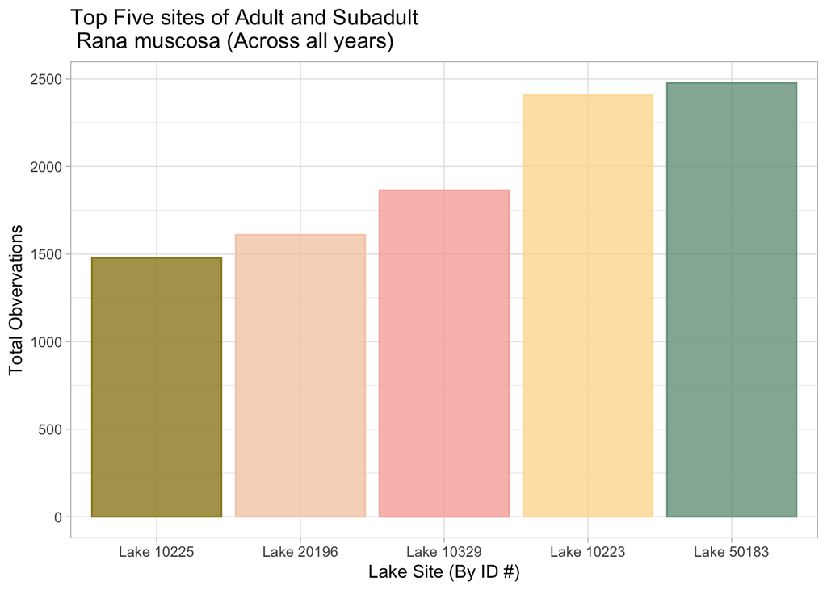

```r
rana_lake_graph <- ggplot(data = ramu_by_lake, aes(x = lake_id, y = total)) +
  geom_col(aes(fill = lake_id, color = lake_id),
           alpha = 0.8,
           show.legend = FALSE) +
  scale_fill_manual(values=wes_palette(n=5, name="Royal2")) +
  scale_color_manual(values=wes_palette(n=5, name="Royal2")) +
  labs( x = "Lake Site (By ID #)", y = "Total Obvervations", title = "Top Five sites of Adult and Subadult \n Rana muscosa (Across all years)") +
  theme_light()


rana_lake_graph
```

Now that have these two graphs of *Rana muscosa*, I am plotting them together, using the patchwork package.

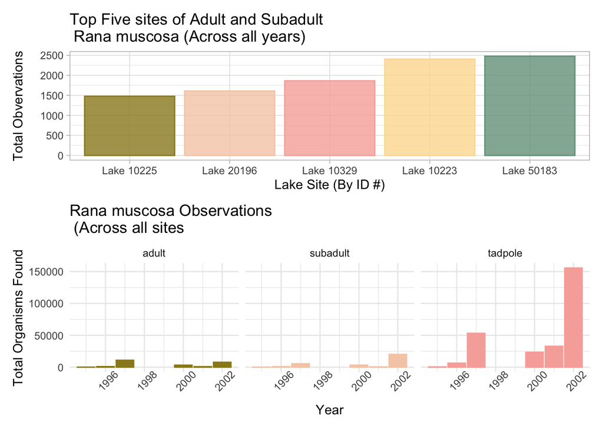

```r
rana_lake_graph / rana_year_graph
```